# Statistical Inference Course Project

Daniel Pont

2018-09-30

## Simulation of the Central Limit Theorem with exponential distribution averages

#### 1) Let’s simulate 1000 exponential distributions of n=40 values with parameter lambda=0.2

For each one we calculate it’s mean and put it into the vector rexpMeanDist

```r
lambda <- 0.2
n  <- 40
rexpMeansDist = NULL
for (i in 1 : 1000) rexpMeansDist = c(rexpMeansDist, mean(rexp(n = n, rate=lambda)))
```

### 2) Now let’s compare theoritical and simulation values for both mean and variance :

- **The theoritical mean for the distribution of averages**  
  as predicted by the Central Limit Theorem is the mean of the exponential :

```r
1/lambda
```

```
## [1] 5
```

- **The simulation mean is** :

```r
mean(rexpMeansDist)
```

```
## [1] 4.990025
```

- **The theoritical variance for the distribution of averages**  
  as predicted by the Central Limit Theorem is the variance of the exponential / n :

```r
1/lambda^2/n
```

```
## [1] 0.625
```

- **The simulation variance is** :

```r
var(rexpMeansDist)
```

```
## [1] 0.6111165
```

To sum up :

| Value | Theoritical | Simulation |
| --- | --- | --- |
| Mean | 5 | 4.99 |
| Variance | 0.625 | 0.611 |

- Theoritical and simulation values for both mean and variance are pretty close
- The mean of the averages distribution is the mean of the exponential
- The variance of the averages distribution is much smaller than the variance of the exponential  
  (1/lambda^2/n = 0.625 vs 1/lambda^2 = 25).

## APPENDIX

### 1) Simulation plot

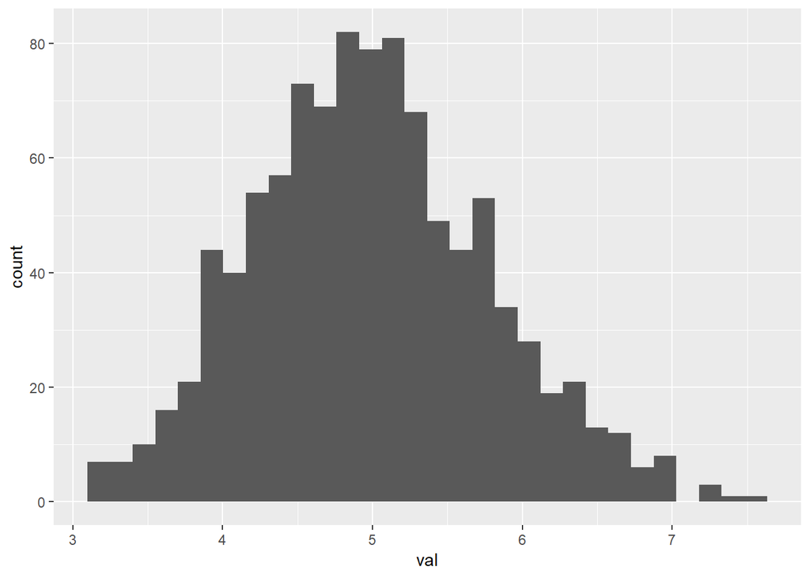

```r
data_frame(val=rexpMeansDist) %>%
    ggplot(., aes(val)) +
                geom_histogram()
```